# Expression data processing

Erica Padial Fuillerat

25/7/2020

# Data processing

Data loading:

```r
Data_normalized <- read.delim("/media/erica/ERIKA/copia/MASTER/Segundo_cuatrimestre/TFM/Data_normalized.txt",row.names = 1)
data_n2 <- read.delim("/media/erica/ERIKA/copia/MASTER/Segundo_cuatrimestre/TFM/Data_normalized.txt")

library(readxl)
Probes_tables <- read_excel("/media/erica/ERIKA/copia/MASTER/Segundo_cuatrimestre/TFM/Probes_tables.xlsx")
print(Data_normalized[1:5,1:10])
```

```
##            P1_.HTA.2_0..CEL P10_.HTA.2_0..CEL P100_.HTA.2_0..CEL
## 2824546_st         9.238760          7.742420           8.981395
## 2824549_st         9.266066          8.542074           9.346652
## 2824551_st         8.618568          7.295439           8.852179
## 2824554_st         8.720610          7.019586           8.297426
## 2827992_st         8.409097          7.243882           8.286300
##            P101_.HTA.2_0..CEL P102_.HTA.2_0..CEL P103_.HTA.2_0..CEL
## 2824546_st           7.540774           8.072721           8.348843
## 2824549_st           8.958386           8.467412           8.863048
## 2824551_st           7.991099           7.345319           7.172341
## 2824554_st           6.888815           6.399062           6.307125
## 2827992_st           7.623005           7.831898           6.698919
##            P104_.HTA.2_0..CEL P105_.HTA.2_0..CEL P106_.HTA.2_0..CEL
## 2824546_st           8.147218           9.523822           7.922986
## 2824549_st           9.163002           9.758044           8.722133
## 2824551_st           7.817981           9.203614           7.734386
## 2824554_st           8.224180           8.873399           7.109109
## 2827992_st           7.444097           9.031854           7.906773
##            P107_.HTA.2_0..CEL
## 2824546_st           8.984712
## 2824549_st           9.309675
## 2824551_st           8.408617
## 2824554_st           8.292698
## 2827992_st           7.685347
```

```r
print(Probes_tables[1:5,1:4])
```

```
## # A tibble: 5 x 4
##   PROBEID       ID             SYMBOL     GENENAME
##   <chr>         <chr>          <chr>      <chr>
## 1 TC01000001.h… NR_046018      DDX11L1    DEAD/H (Asp-Glu-Ala-Asp/His) box heli…
## 2 TC01000002.h… ENST000004083… MIR1302-11 microRNA 1302-11
## 3 TC01000003.h… NM_001005484   OR4F5      olfactory receptor, family 4, subfami…
## 4 TC01000004.h… OTTHUMT000000… RP11-34P1… putative novel transcript
## 5 TC01000005.h… NR_028322      LOC100132… uncharacterized LOC100132287
```

Reversing our dataframe to have probes as columns and patients as rows: We make the transposition to Data_normalized:

```r
dn_transpose <- data.frame(t(Data_normalized))
```

We eliminate all those probes with variance 0 if there are any:

```r
library(caret)
nzv <- nearZeroVar(dn_transpose)
```

As there are no probes with variance 0, we continue processing with our data frame “Data_normalized” without reversing.

Displaying variation coefficient of all the probes:

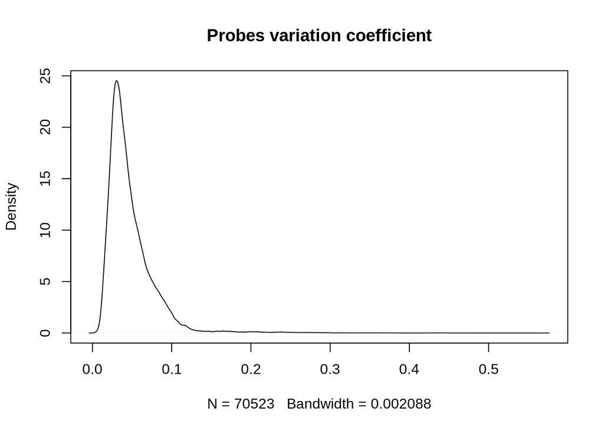

```r
cv <- function (x, na.rm=FALSE){
  sd(x, na.rm=na.rm)/mean(x, na.rm=na.rm)
}
cvs_Data_normalized = apply(Data_normalized,1,cv,na.rm=T)
plot(density(na.omit(cvs_Data_normalized)),main=paste0("Probes variation coefficient"))
```

We obtain a new data frame with our interesting probes (the main ones), and patients expression data:

```r
data_sondpa <- data.frame()
sondprin <- match(Probes_tables$PROBEID,data_n2$X)  #Save the number of rows that correspond to main probes (which are in Probes_tables) in data_n2.
for (probe in (sondprin)){    #For each row (of the main ones)
    data_sondpa <- rbind(data_sondpa,Data_normalized[probe,])  #Insert in data_sondpa that row which is a main probe, with its corresponding expression data.
}
```

```r
data_sondpa <- readRDS("/media/erica/ERIKA/copia/MASTER/Segundo_cuatrimestre/TFM/RDSs_procesamiento_datos_expresion/data_sondpa.rds")
print(data_sondpa[1:5,1:10])
```

```
##                 P1_.HTA.2_0..CEL P10_.HTA.2_0..CEL P100_.HTA.2_0..CEL
## TC01000001.hg.1         7.881041          8.659490           8.126683
## TC01000002.hg.1         5.068482          5.071072           5.284580
## TC01000003.hg.1         3.664118          3.436562           3.541158
## TC01000004.hg.1         6.297127          6.133762           6.509271
## TC01000005.hg.1        11.472437         11.342370          11.210811
##                 P101_.HTA.2_0..CEL P102_.HTA.2_0..CEL P103_.HTA.2_0..CEL
## TC01000001.hg.1           8.209916           8.795893           9.060370
## TC01000002.hg.1           5.257322           5.232791           5.346024
## TC01000003.hg.1           3.591592           3.857389           3.271271
## TC01000004.hg.1           7.279326           6.689103           6.394025
## TC01000005.hg.1          11.741270          10.986072          11.038237
##                 P104_.HTA.2_0..CEL P105_.HTA.2_0..CEL P106_.HTA.2_0..CEL
## TC01000001.hg.1           8.511937           7.866041           8.476040
## TC01000002.hg.1           5.163537           5.312518           5.311930
## TC01000003.hg.1           3.547384           3.883570           3.458675
## TC01000004.hg.1           6.422100           6.266513           6.158542
## TC01000005.hg.1          11.158437          10.781017          11.378128
##                 P107_.HTA.2_0..CEL
## TC01000001.hg.1           6.637664
## TC01000002.hg.1           5.489933
## TC01000003.hg.1           3.243427
## TC01000004.hg.1           6.408766
## TC01000005.hg.1          11.051222
```

Creating a data frame composed of the probes, the genes to which they correspond and the expression data:

```r
sond_gen <- data.frame(Probes_tables[1],Probes_tables[3],data_sondpa[1:ncol(data_sondpa)])  #Enter the names of Probes_tables probes, Probes_tables genes and all patients data in sond_gen. With this data frame we can verify that data_sondpa and Probes_tables probes are the same and they are in the same order.
print(sond_gen[1:5,1:10])
```

```
##                         PROBEID       SYMBOL P1_.HTA.2_0..CEL P10_.HTA.2_0..CEL
## TC01000001.hg.1 TC01000001.hg.1      DDX11L1         7.881041          8.659490
## TC01000002.hg.1 TC01000002.hg.1   MIR1302-11         5.068482          5.071072
## TC01000003.hg.1 TC01000003.hg.1        OR4F5         3.664118          3.436562
## TC01000004.hg.1 TC01000004.hg.1 RP11-34P13.9         6.297127          6.133762
## TC01000005.hg.1 TC01000005.hg.1 LOC100132287        11.472437         11.342370
##                 P100_.HTA.2_0..CEL P101_.HTA.2_0..CEL P102_.HTA.2_0..CEL
## TC01000001.hg.1           8.126683           8.209916           8.795893
## TC01000002.hg.1           5.284580           5.257322           5.232791
## TC01000003.hg.1           3.541158           3.591592           3.857389
## TC01000004.hg.1           6.509271           7.279326           6.689103
## TC01000005.hg.1          11.210811          11.741270          10.986072
##                 P103_.HTA.2_0..CEL P104_.HTA.2_0..CEL P105_.HTA.2_0..CEL
## TC01000001.hg.1           9.060370           8.511937           7.866041
## TC01000002.hg.1           5.346024           5.163537           5.312518
## TC01000003.hg.1           3.271271           3.547384           3.883570
## TC01000004.hg.1           6.394025           6.422100           6.266513
## TC01000005.hg.1          11.038237          11.158437          10.781017
```

```r
data_sondgen <- data.frame(sond_gen, row.names = 1) #We put the probes names as rownames.
print(data_sondgen[1:5,1:10])
```

```
##                       SYMBOL P1_.HTA.2_0..CEL P10_.HTA.2_0..CEL
## TC01000001.hg.1      DDX11L1         7.881041          8.659490
## TC01000002.hg.1   MIR1302-11         5.068482          5.071072
## TC01000003.hg.1        OR4F5         3.664118          3.436562
## TC01000004.hg.1 RP11-34P13.9         6.297127          6.133762
## TC01000005.hg.1 LOC100132287        11.472437         11.342370
##                 P100_.HTA.2_0..CEL P101_.HTA.2_0..CEL P102_.HTA.2_0..CEL
## TC01000001.hg.1           8.126683           8.209916           8.795893
## TC01000002.hg.1           5.284580           5.257322           5.232791
## TC01000003.hg.1           3.541158           3.591592           3.857389
## TC01000004.hg.1           6.509271           7.279326           6.689103
## TC01000005.hg.1          11.210811          11.741270          10.986072
##                 P103_.HTA.2_0..CEL P104_.HTA.2_0..CEL P105_.HTA.2_0..CEL
## TC01000001.hg.1           9.060370           8.511937           7.866041
## TC01000002.hg.1           5.346024           5.163537           5.312518
## TC01000003.hg.1           3.271271           3.547384           3.883570
## TC01000004.hg.1           6.394025           6.422100           6.266513
## TC01000005.hg.1          11.038237          11.158437          10.781017
##                 P106_.HTA.2_0..CEL
## TC01000001.hg.1           8.476040
## TC01000002.hg.1           5.311930
## TC01000003.hg.1           3.458675
## TC01000004.hg.1           6.158542
## TC01000005.hg.1          11.378128
```

We are left only with those rows whose probes have an assigned gene:

```r
data_sondgen_final <- data.frame()
for (gen in (seq(nrow(data_sondgen)))){ #Runs through each row (each gene)
  if (!is.na(data_sondgen[gen,1])){   #if the gene value of that row is not NA
    data_sondgen_final <- rbind(data_sondgen_final,data_sondgen[gen,])  #in data_sondgen_final we will add only those genes whose value were different from NA.
  }
}
```

```r
data_sondgen_final <- readRDS("/media/erica/ERIKA/copia/MASTER/Segundo_cuatrimestre/TFM/RDSs_procesamiento_datos_expresion/data_sondgen_final.rds")
print(data_sondgen_final[1:5,1:10])
```

```
##                       SYMBOL P1_.HTA.2_0..CEL P10_.HTA.2_0..CEL
## TC01000001.hg.1      DDX11L1         7.881041          8.659490
## TC01000002.hg.1   MIR1302-11         5.068482          5.071072
## TC01000003.hg.1        OR4F5         3.664118          3.436562
## TC01000004.hg.1 RP11-34P13.9         6.297127          6.133762
## TC01000005.hg.1 LOC100132287        11.472437         11.342370
##                 P100_.HTA.2_0..CEL P101_.HTA.2_0..CEL P102_.HTA.2_0..CEL
## TC01000001.hg.1           8.126683           8.209916           8.795893
## TC01000002.hg.1           5.284580           5.257322           5.232791
## TC01000003.hg.1           3.541158           3.591592           3.857389
## TC01000004.hg.1           6.509271           7.279326           6.689103
## TC01000005.hg.1          11.210811          11.741270          10.986072
##                 P103_.HTA.2_0..CEL P104_.HTA.2_0..CEL P105_.HTA.2_0..CEL
## TC01000001.hg.1           9.060370           8.511937           7.866041
## TC01000002.hg.1           5.346024           5.163537           5.312518
## TC01000003.hg.1           3.271271           3.547384           3.883570
## TC01000004.hg.1           6.394025           6.422100           6.266513
## TC01000005.hg.1          11.038237          11.158437          10.781017
##                 P106_.HTA.2_0..CEL
## TC01000001.hg.1           8.476040
## TC01000002.hg.1           5.311930
## TC01000003.hg.1           3.458675
## TC01000004.hg.1           6.158542
## TC01000005.hg.1          11.378128
```

As the same gene can correspond to several different probes and therefore, to have several expression data, we will locate those probes that correspond to the same gene, will make the average to the expression data, and will assign this average per patient to the gene. Finally we will obtain two data frames: in one of them duplicated genes with the mean of their data will be put, and another one with non duplicated genes data. We will join the two data frames in one to finish.

Obtaining the data frame with the duplicated genes mean:

```r
library(dplyr)
duplicates <- data_sondgen_final[duplicated(data_sondgen_final$SYMBOL),1]  #The function "duplicated" takes those duplicated genes and stores only the copies names, that is, if Y is duplicated 3 times (Y, Y, Y), this code will only save the last two repetitions since the first one is the original and does not consider it repeated.
duplicates_unic <- duplicates[!duplicated(duplicates)]  #This time we use negated form of function "duplicated" for last vector created to obtain the repeated genes names only once (and not all the repetitions as copies of them).
media.gen.paciente <- data.frame()  #This will be the dataframe with those duplicated genes with the means of their copies.

for (gen in (seq(duplicates_unic))){  #Looping through each duplicated gene.
  fila <- match(duplicates_unic[gen],data_sondgen_final$SYMBOL) #We get the row where this duplicated gene is found in data_sondgen_final.
  mean_gen <- data_sondgen_final %>% filter(SYMBOL == data_sondgen_final[fila,1])  #mean_gen will get that gene plus all its copies with all its expression data.
  mean <- data.frame(t(colMeans(mean_gen[2:101])))  #mean will save the mean per column (per patient) of the copies for that gene, but without the gene name.
  gen.sindup <- data.frame(mean_gen[1,1],mean)  #gen.sindup is the data frame that stores both the gene name and the average obtained in last step.
  gen.sindup <- rename(gen.sindup,SYMBOL=mean_gen.1..1.)  #In previous gen.sindup, genes' variable name varies from the original (which is SYMBOL), so it must be renamed to be able to work with this data frame later.
  media.gen.paciente <- rbind(media.gen.paciente,gen.sindup)  #gen.sindup is introduced to the previously initialized data frame, that is, the gene with patients' expression data mean.
}
```

Obtaining the data frame of the non duplicated genes and their expression data:

```r
genesinduplic <- data.frame() #This data frame will have those genes (and their patients) that were not in duplicates_unic.

for (gen in (seq(nrow(data_sondgen_final)))){ #We loop through each gene in data_sondgen_final.
  if (is.na(match(data_sondgen_final[gen,1],media.gen.paciente$SYMBOL))){ #If the gene is not in media.gen.patient (which is where the duplicates are).
    genesinduplic <- rbind(genesinduplic,data_sondgen_final[gen,])  #It will save that gene with its expression data in genesinduplic.
  }
}
```

Finally we join the two data frames created in gen.paciente.final:

```r
gen.paciente.final <- data.frame(media.gen.paciente)  #We first introduce the genes that were duplicated.
gen.paciente.final <- rbind(gen.paciente.final,genesinduplic) #Next, we add the genes without duplicating.
gen.paciente.final <- data.frame(gen.paciente.final, row.names = 1) #We leave the genes as row names.
```

```r
gen.paciente.final <- readRDS("/media/erica/ERIKA/copia/MASTER/Segundo_cuatrimestre/TFM/RDSs_procesamiento_datos_expresion/gen_paciente_final.rds")
print(gen.paciente.final[1:5,1:10])
```

```
##              P1_.HTA.2_0..CEL P10_.HTA.2_0..CEL P100_.HTA.2_0..CEL
## LOC100287934         6.298455          6.451169           6.086466
## PRAMEF9              3.928698          4.070212           4.412015
## PRAMEF20             4.833226          5.306219           5.180689
## MIR3675              6.769838          7.064452           7.143995
## RNU1-4               5.480101          5.565977           5.603329
##              P101_.HTA.2_0..CEL P102_.HTA.2_0..CEL P103_.HTA.2_0..CEL
## LOC100287934           5.943090           5.996169           5.965976
## PRAMEF9                4.262212           4.340257           4.354206
## PRAMEF20               4.956956           5.202614           5.317324
## MIR3675                6.965070           7.056432           7.075603
## RNU1-4                 5.553755           5.656036           5.717884
##              P104_.HTA.2_0..CEL P105_.HTA.2_0..CEL P106_.HTA.2_0..CEL
## LOC100287934           6.378463           5.672266           6.207682
## PRAMEF9                4.261813           4.446546           4.264063
## PRAMEF20               5.325189           5.418552           5.171975
## MIR3675                6.957729           7.521060           7.073856
## RNU1-4                 5.502867           5.862989           5.537215
##              P107_.HTA.2_0..CEL
## LOC100287934           5.910074
## PRAMEF9                4.337427
## PRAMEF20               5.120759
## MIR3675                7.130713
## RNU1-4                 5.622576
```

# Correlation analysis

Making the variation coefficients graph again, this time with our last data frame, which have filtered genes and patients:

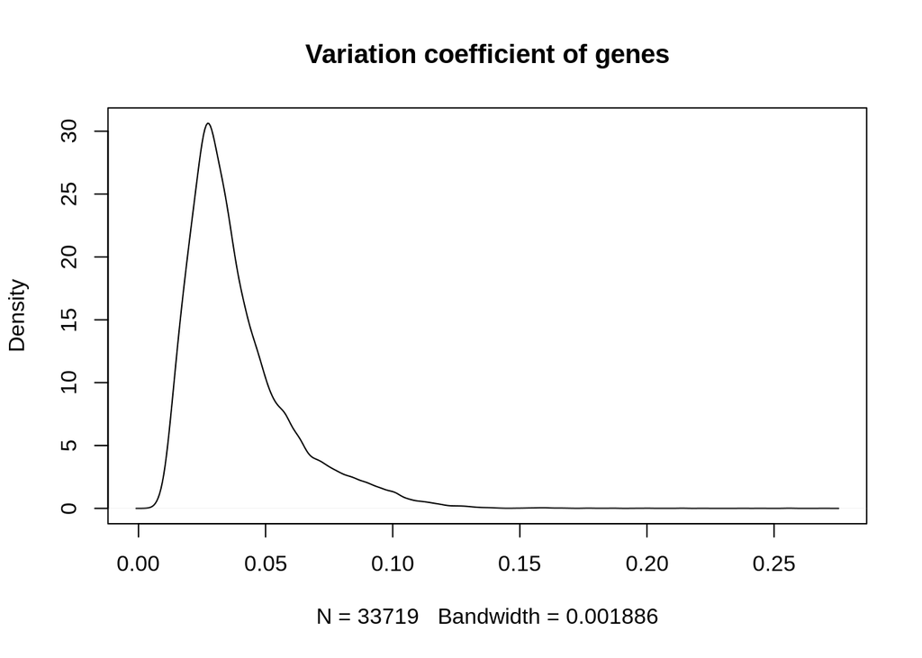

```r
cvs_gen.paciente.final = apply(gen.paciente.final,1,cv,na.rm=T) #Application of variation coefficient to each gene of gen.patient.final.
plot(density(na.omit(cvs_gen.paciente.final)),main=paste0("Variation coefficient of genes"))
```

We group these variation coefficients in intervals to represent them in a histogram:

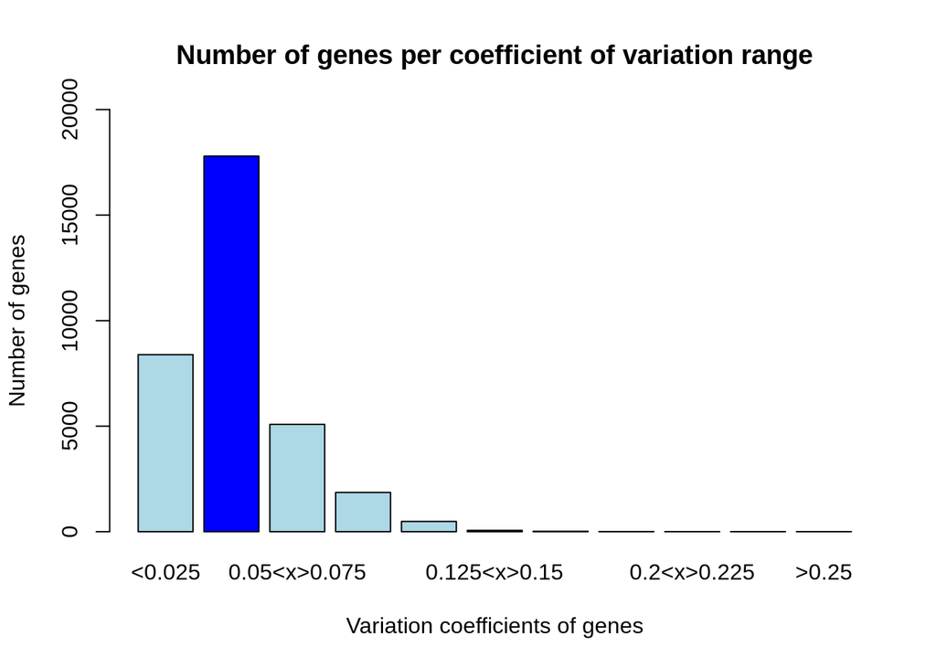

```r
data_cvs<- data.frame(cvs_gen.paciente.final) #We convert the numerical vector with the coefficients of variation of gen.patient.final into data frame.
L = c(0,0.025,0.05,0.075,0.1,0.125,0.15,0.175,0.2,0.225,0.25,0.275) #We write the ends of the intervals that we want to create.
etiq = c("<0.025","0.025<x>0.05","0.05<x>0.075","0.075<x>0.1","0.1<x>0.125","0.125<x>0.15","0.15<x>0.175","0.175<x>0.2","0.2<x>0.225","0.225<x>0.25",">0.25") #We write the label for each interval.
fac_cvs = cut(data_cvs$cvs_gen.paciente.final,breaks = L,labels = etiq,right = FALSE) #With the cut function we apply the ends of the intervals to our data and labels, and group them.
data_cvs <- cbind(data_cvs,fac_cvs) #We add the new column of the labeled genes according to their cv.
plot(data_cvs$fac_cvs, col= c("lightblue","blue","lightblue","lightblue","lightblue","lightblue","lightblue","lightblue","lightblue"),xlab="Variation coefficients of genes",ylab="Number of genes", main="Number of genes per coefficient of variation range", ylim=c(0,20000))  #We represent it.
```

Selection of genes whose variation coefficient is between 0.025 and 0.05 to subsequently perform the network with them:

```r
genes <- data.frame(row.names(gen.paciente.final),gen.paciente.final[1:100])#Creating a data frame with genes names in columns and the 100 patients columns, since in gen.patient.final the genes are row names and we cannot loop through them.
genes.en.intervalo <- data_cvs[data_cvs$fac_cvs == "0.025<x>0.05",]#We select the genes whose variation coefficients meet that condition.
genes.para.red <- data.frame()

for (gen in (seq(nrow(genes)))){  #Going through each row of genes
  fila <- match(genes[gen,1],row.names(genes.en.intervalo))
  if (is.na(fila)==FALSE){
    genes.para.red <- rbind(genes.para.red,genes[gen,])
  }
}

genes.para.red <- data.frame(genes.para.red,row.names = 1)  #We put the genes as row names.
genes.para.red <- data.frame(t(genes.para.red)) #We place genes as columns and patients as rows.
genes.para.red <- genes.para.red[(-c(96:100)),] #We eliminate the last 5 patients because they are controls (healthy) and we are not interested in having them online.
```

```r
genes.para.red <- readRDS("/media/erica/ERIKA/copia/MASTER/Segundo_cuatrimestre/TFM/RDSs_procesamiento_datos_expresion/genes_para_red.rds")
print(genes.para.red[1:5,1:10])
```

```
##                    LOC100287934  PRAMEF9 PRAMEF20  MIR3675 RP11.442N24__B.1
## P1_.HTA.2_0..CEL       6.298455 3.928698 4.833226 6.769838         3.487078
## P10_.HTA.2_0..CEL      6.451169 4.070212 5.306219 7.064452         3.615988
## P100_.HTA.2_0..CEL     6.086466 4.412015 5.180689 7.143995         3.505017
## P101_.HTA.2_0..CEL     5.943090 4.262212 4.956956 6.965070         3.786549
## P102_.HTA.2_0..CEL     5.996169 4.340257 5.202614 7.056432         3.811299
##                        AGO1 DAB1.AS1 ZRANB2.AS2    AMY1B CTTNBP2NL
## P1_.HTA.2_0..CEL   3.947394 2.487996   3.802476 4.445340  5.986421
## P10_.HTA.2_0..CEL  4.122472 2.644327   3.877354 4.539643  5.786811
## P100_.HTA.2_0..CEL 4.168455 2.505786   3.770051 4.552130  5.402512
## P101_.HTA.2_0..CEL 4.072784 2.608141   3.842769 4.563991  5.406439
## P102_.HTA.2_0..CEL 4.103754 2.680553   3.652050 4.595455  5.454295
```